# task_1_instructions_without_code

```python
import pandas as pd
import numpy as np
import matplotlib.pyplot as plt
import datetime as dt
```

**Variable description** (check the burners_dwg.pdf):

- 'FUEL OIL TO BOILER FLOW (T/H)' - sum of all fuel injected to the boiler (from all burners)
- 'BURNER FLAME SENSOR, BURNER 4' - sensor of flame brightness [%]
- 'FUEL OIL FLOW UPSTREAM BOILER (T/H)' - fuel flow to the boiler - **09PF001**
- 'FUEL OIL FLOW DOWNSTREAM BOILER (T/H)' - fuel flow downstream the boiler - **09PF002**
- 'STEAM PRESSURE, RING 1' - **09PP008**
- 'FUEL OIL PRESSURE, RING 1' - **09PP006**
- 'FUEL OIL PRESSURE UPSTREAM OIL FILTER' - **09PP015**
- 'FUEL OIL PRESSURE DOWNSTREAM OIL FILTER' - **09PP017**
- 'I&C AIR PRESSURE' - **09PP082** [kPa]
- 'COOLING AIR PRESSURE' - **09PP084** [kPa]
- 'FUEL OIL PRESSURE DOWNSTREAM THREE-WAY VALVE' - **09PP412** [MPa]
- 'STEAM PRESSURE DOWNSTREAM THREE-WAY VALVE' - **09PP422** [MPa]
- 'FUEL OIL TEMPERATURE (DEG C)' - **09PT005** [°C]
- 'FUEL OIL CONTROL VALVE POSITION, RING 1' - **AR036**
- 'POWER OUTPUT (MW)' - output power of the plant,
- 'STEAM TEMPERATURE' - **09PT004** [°C]

Read the 'burner_4_startup.csv' to dataframe.

```python
df = pd.read_csv('burner_4_startup.csv')
df
```

|  | timestamp | FUEL OIL TO BOILER FLOW (T/H) | BURNER FLAME SENSOR, BURNER 4 | FUEL OIL FLOW UPSTREAM BOILER (T/H) | FUEL OIL FLOW DOWNSTREAM BOILER (T/H) | STEAM PRESSURE, RING 1 | FUEL OIL PRESSURE, RING 1 | FUEL OIL PRESSURE UPSTREAM OIL FILTER | FUEL OIL PRESSURE DOWNSTREAM OIL FILTER | I&C AIR PRESSURE | COOLING AIR PRESSURE | FUEL OIL PRESSURE DOWNSTREAM THREE-WAY VALVE | STEAM PRESSURE DOWNSTREAM THREE-WAY VALVE | FUEL OIL TEMPERATURE (DEG C) | FUEL OIL CONTROL VALVE POSITION, RING 1 | POWER OUTPUT (MW) | STEAM TEMPERATURE |
| --- | --- | --- | --- | --- | --- | --- | --- | --- | --- | --- | --- | --- | --- | --- | --- | --- | --- |
| 0 | 2015-06-12 19:36:00 | 0.0 | -1.09 | 1.11 | 1.01 | -0.00 | 0.45 | 1.37 | 1.37 | 688.86 | 0.09 | 0.00 | -0.00 | 95.70 | 10.64 | -0.37 | 263.925000 |
| 1 | 2015-06-12 19:36:01 | 0.0 | -1.09 | 1.11 | 1.01 | -0.00 | 0.45 | 1.37 | 1.37 | 688.79 | 0.09 | 0.00 | -0.00 | 95.70 | 10.64 | -0.37 | 263.925000 |
| 2 | 2015-06-12 19:36:02 | 0.0 | -1.09 | 1.11 | 1.01 | -0.00 | 0.45 | 1.37 | 1.37 | 688.73 | 0.09 | 0.00 | -0.00 | 95.70 | 10.64 | -0.37 | 263.925000 |
| 3 | 2015-06-12 19:36:03 | 0.0 | -1.09 | 1.11 | 1.01 | -0.00 | 0.45 | 1.37 | 1.37 | 688.67 | 0.09 | 0.00 | -0.00 | 95.70 | 10.64 | -0.37 | 263.925000 |
| 4 | 2015-06-12 19:36:04 | 0.0 | -1.09 | 1.11 | 1.01 | -0.00 | 0.45 | 1.37 | 1.37 | 688.61 | 0.09 | 0.00 | -0.00 | 95.70 | 10.63 | -0.37 | 263.925000 |
| ... | ... | ... | ... | ... | ... | ... | ... | ... | ... | ... | ... | ... | ... | ... | ... | ... | ... |
| 64795 | 2015-06-13 13:35:56 | 0.0 | -1.33 | 2.89 | 2.94 | 0.96 | 0.45 | 1.36 | 1.36 | 663.14 | 10.45 | 0.22 | 0.08 | 110.61 | 17.35 | 132.90 | 268.183084 |
| 64796 | 2015-06-13 13:35:57 | 0.0 | -1.33 | 2.89 | 2.94 | 0.96 | 0.45 | 1.36 | 1.36 | 663.30 | 10.50 | 0.22 | 0.08 | 110.61 | 17.35 | 132.89 | 268.183018 |
| 64797 | 2015-06-13 13:35:58 | 0.0 | -1.33 | 2.89 | 2.94 | 0.96 | 0.45 | 1.36 | 1.36 | 663.47 | 10.55 | 0.22 | 0.08 | 110.61 | 17.35 | 132.89 | 268.182952 |
| 64798 | 2015-06-13 13:35:59 | 0.0 | -1.33 | 2.89 | 2.94 | 0.96 | 0.45 | 1.36 | 1.36 | 663.64 | 10.60 | 0.22 | 0.08 | 110.61 | 17.35 | 132.89 | 268.182885 |
| 64799 | 2015-06-13 13:36:00 | 0.0 | -1.33 | 2.89 | 2.94 | 0.96 | 0.45 | 1.36 | 1.36 | 663.81 | 10.60 | 0.22 | 0.08 | 110.61 | 17.35 | 132.89 | 268.182819 |

64800 rows × 17 columns

|  | timestamp | FUEL OIL TO BOILER FLOW (T/H) | BURNER FLAME SENSOR, BURNER 4 | FUEL OIL FLOW UPSTREAM BOILER (T/H) | FUEL OIL FLOW DOWNSTREAM BOILER (T/H) | STEAM PRESSURE, RING 1 | FUEL OIL PRESSURE, RING 1 | FUEL OIL PRESSURE UPSTREAM OIL FILTER | FUEL OIL PRESSURE DOWNSTREAM OIL FILTER | I&C AIR PRESSURE | COOLING AIR PRESSURE | FUEL OIL PRESSURE DOWNSTREAM THREE-WAY VALVE | STEAM PRESSURE DOWNSTREAM THREE-WAY VALVE | FUEL OIL TEMPERATURE (DEG C) | FUEL OIL CONTROL VALVE POSITION, RING 1 | POWER OUTPUT (MW) | STEAM TEMPERATURE |
| --- | --- | --- | --- | --- | --- | --- | --- | --- | --- | --- | --- | --- | --- | --- | --- | --- | --- |
| 0 | 2015-06-12 19:36:00 | 0.0 | -1.09 | 1.11 | 1.01 | -0.00 | 0.45 | 1.37 | 1.37 | 688.86 | 0.09 | 0.00 | -0.00 | 95.70 | 10.64 | -0.37 | 263.925000 |
| 1 | 2015-06-12 19:36:01 | 0.0 | -1.09 | 1.11 | 1.01 | -0.00 | 0.45 | 1.37 | 1.37 | 688.79 | 0.09 | 0.00 | -0.00 | 95.70 | 10.64 | -0.37 | 263.925000 |
| 2 | 2015-06-12 19:36:02 | 0.0 | -1.09 | 1.11 | 1.01 | -0.00 | 0.45 | 1.37 | 1.37 | 688.73 | 0.09 | 0.00 | -0.00 | 95.70 | 10.64 | -0.37 | 263.925000 |
| 3 | 2015-06-12 19:36:03 | 0.0 | -1.09 | 1.11 | 1.01 | -0.00 | 0.45 | 1.37 | 1.37 | 688.67 | 0.09 | 0.00 | -0.00 | 95.70 | 10.64 | -0.37 | 263.925000 |
| 4 | 2015-06-12 19:36:04 | 0.0 | -1.09 | 1.11 | 1.01 | -0.00 | 0.45 | 1.37 | 1.37 | 688.61 | 0.09 | 0.00 | -0.00 | 95.70 | 10.63 | -0.37 | 263.925000 |
| ... | ... | ... | ... | ... | ... | ... | ... | ... | ... | ... | ... | ... | ... | ... | ... | ... | ... |
| 64795 | 2015-06-13 13:35:56 | 0.0 | -1.33 | 2.89 | 2.94 | 0.96 | 0.45 | 1.36 | 1.36 | 663.14 | 10.45 | 0.22 | 0.08 | 110.61 | 17.35 | 132.90 | 268.183084 |
| 64796 | 2015-06-13 13:35:57 | 0.0 | -1.33 | 2.89 | 2.94 | 0.96 | 0.45 | 1.36 | 1.36 | 663.30 | 10.50 | 0.22 | 0.08 | 110.61 | 17.35 | 132.89 | 268.183018 |
| 64797 | 2015-06-13 13:35:58 | 0.0 | -1.33 | 2.89 | 2.94 | 0.96 | 0.45 | 1.36 | 1.36 | 663.47 | 10.55 | 0.22 | 0.08 | 110.61 | 17.35 | 132.89 | 268.182952 |
| 64798 | 2015-06-13 13:35:59 | 0.0 | -1.33 | 2.89 | 2.94 | 0.96 | 0.45 | 1.36 | 1.36 | 663.64 | 10.60 | 0.22 | 0.08 | 110.61 | 17.35 | 132.89 | 268.182885 |
| 64799 | 2015-06-13 13:36:00 | 0.0 | -1.33 | 2.89 | 2.94 | 0.96 | 0.45 | 1.36 | 1.36 | 663.81 | 10.60 | 0.22 | 0.08 | 110.61 | 17.35 | 132.89 | 268.182819 |

64800 rows × 17 columns

Plot all the variables, have a look at them.

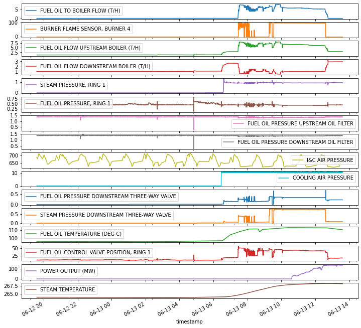

```python
sub1 = df.copy()
sub1['timestamp'] = pd.to_datetime(sub1['timestamp'])
sub1.plot(x='timestamp', subplots=True, figsize=(12,12));
```

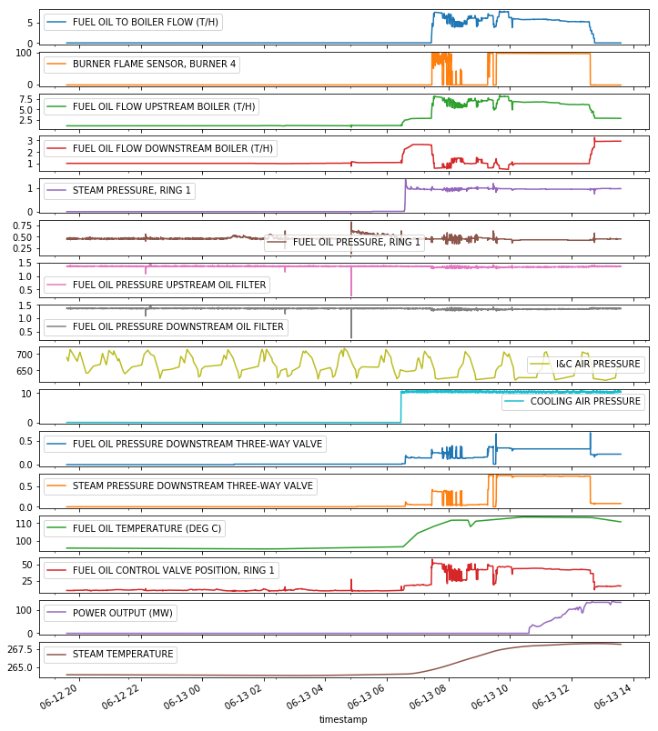

Basing on the data you have:

#### Identify the beginning and the end of the whole startup sequence. For the purpose of this task let's assume that startup sequence is the period of time in which oil burners are used.

```python
sub1 = sub1[sub1['FUEL OIL TO BOILER FLOW (T/H)']>0]
print('The whole startup sequence started at {} and finished at {}'.format(sub1.loc[sub1.index[0],'timestamp'],
                                                                           sub1.loc[sub1.index[-1],'timestamp']))
```

```
The whole startup sequence started at 2015-06-13 07:26:39 and finished at 2015-06-13 12:44:54
```

```
The whole startup sequence started at 2015-06-13 07:26:39 and finished at 2015-06-13 12:44:54
```

#### Recreate FUEL OIL TO BOILER FLOW measurement using other measurements. Plot the signal you recreated and the actual FUEL OIL TO BOILER FLOW measurement on single plot. Calculate the difference between these two. Plot the absolute difference in time. Remember about axis labels and the legend! Add units if missing.

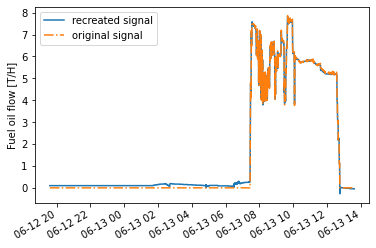

```python
sub2 = df.copy()
sub2['timestamp'] = pd.to_datetime(sub2['timestamp'])
sub2['rec_signal'] = sub2.apply(lambda x: x['FUEL OIL FLOW UPSTREAM BOILER (T/H)'] -
                                x['FUEL OIL FLOW DOWNSTREAM BOILER (T/H)'], axis=1)
sub2.plot(x='timestamp', y=['rec_signal', 'FUEL OIL TO BOILER FLOW (T/H)'],
          ylabel='Fuel oil flow [T/H]', style=['-','-.']);
plt.xlabel(None);
plt.legend(['recreated signal','original signal']);
```

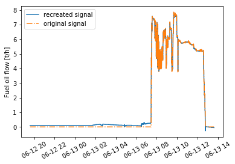

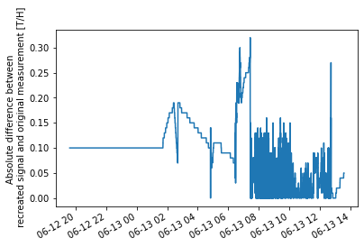

```python
sub2['abs_dif'] = sub2.apply(lambda x: abs(x['FUEL OIL TO BOILER FLOW (T/H)'] - x['rec_signal']), axis=1)
sub2.plot(x='timestamp', y='abs_dif', legend=None,
         ylabel='Absolute difference between \n recreated signal and original measurement [T/H]');
plt.xlabel(None);
```

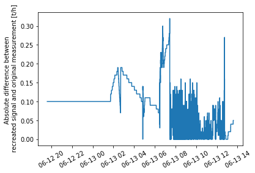

#### Find the moment (timestamp) when first attempt to start the burner # 4 was made. In other words - the moment at which the flame was seen by the brightness sensor for the first time.

```python
sub3 = df.copy()
sub3 = sub3[sub3['BURNER FLAME SENSOR, BURNER 4']>0]
print('The first attempt to fire the burner was made at {}'.format(sub3.loc[sub3.index[0],'timestamp']))
```

```
The first attempt to fire the burner was made at 2015-06-13 07:27:44
```

```
The first attempt to fire the burner was made at 2015-06-13 07:27:44
```

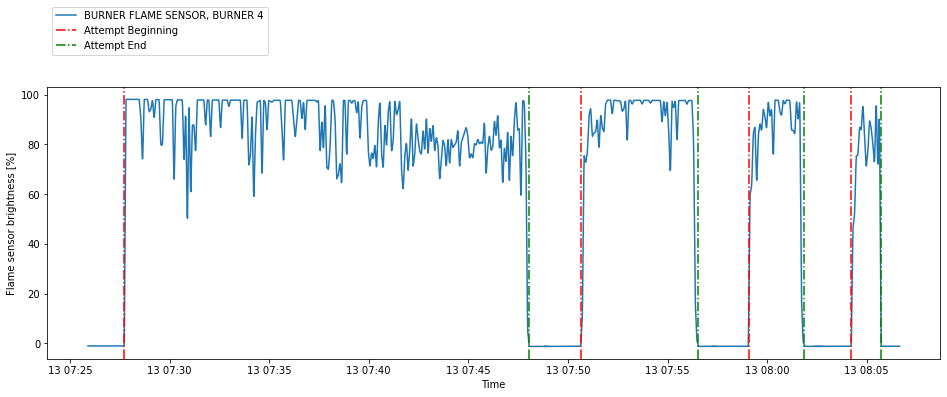

```python
sub4 = df.copy()
sub4['timestamp'] = pd.to_datetime(sub4['timestamp'])
sub4['active'] = sub4.apply(lambda x: 1 if x['BURNER FLAME SENSOR, BURNER 4'] >= 0 else 0, axis=1)
sub4['active_dif'] = sub4['active'].diff()
sub4 = sub4.set_index('timestamp')
starts = sub4[sub4['active_dif']==1]
ends = sub4[sub4['active_dif']==-1]
margin = dt.timedelta(seconds=55)
plt.figure(figsize=(16,5));
plt.ylabel('Flame sensor brightness [%]');
plt.xlabel('Time');

for n, (start, end) in enumerate (zip(starts.index, ends.index)):
    if n < 4:
        plt.plot(sub4.loc[start-2*margin:end+margin, 'BURNER FLAME SENSOR, BURNER 4'], color='tab:blue',
                label='BURNER FLAME SENSOR, BURNER 4')

for i, start in enumerate (starts.index):
    if i < 4:
        plt.axvline(x=start, color='red', label="Attempt Beginning", linestyle='-.')

for j, end in enumerate (ends.index):
    if j < 4:
        plt.axvline(x=end, color='green', label="Attempt End", linestyle='-.')

handles, labels = plt.gca().get_legend_handles_labels()
by_label = dict(zip(labels, handles))
plt.legend(by_label.values(), by_label.keys(), loc='lower left', bbox_to_anchor=(0,1.1));
plt.show()
```

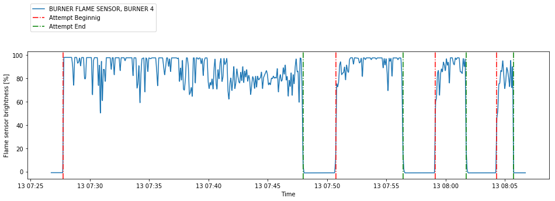

#### For the first 4 attempts, plot flame sensor brightness, fuel pressure and steam pressure downstream the 3-way valve on single plot (see below)

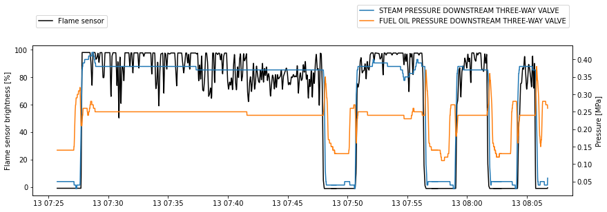

```python
sub5 = df.copy()
sub5['timestamp'] = pd.to_datetime(sub5['timestamp'])
sub5['active'] = sub5.apply(lambda x: 1 if x['BURNER FLAME SENSOR, BURNER 4'] >= 0 else 0, axis=1)
sub5['active_dif'] = sub5['active'].diff()
sub5 = sub5.set_index('timestamp')
starts = sub5[sub5['active_dif']==1]
ends = sub5[sub5['active_dif']==-1]
margin = dt.timedelta(seconds=60)
fig, ax1 = plt.subplots(figsize=(14,4))
ax1.set_ylabel('Flame sensor brightness [%]');
ax2 = ax1.twinx()
ax2.set_ylabel('Pressure [MPa]')
for n, (start, end) in enumerate (zip(starts.index, ends.index)):
    if n < 4:
        p1 = ax1.plot(sub5.loc[start-2*margin:end+margin, 'BURNER FLAME SENSOR, BURNER 4'],
                 label='Flame sensor' if n==0 else "", color='black')
        p2 = ax2.plot(sub5.loc[start-2*margin:end+margin, 'STEAM PRESSURE DOWNSTREAM THREE-WAY VALVE'],
                 label='STEAM PRESSURE DOWNSTREAM THREE-WAY VALVE', color='tab:blue')
        p3 = ax2.plot(sub5.loc[start-2*margin:end+margin, 'FUEL OIL PRESSURE DOWNSTREAM THREE-WAY VALVE'],
                 label='FUEL OIL PRESSURE DOWNSTREAM THREE-WAY VALVE', color='tab:orange')

handles, labels = plt.gca().get_legend_handles_labels()
by_label = dict(zip(labels, handles))
ax1.legend(loc='lower left', bbox_to_anchor=(0,1.1));
plt.legend(by_label.values(), by_label.keys(), loc='lower right', bbox_to_anchor=(1,1.1));
plt.show()
```

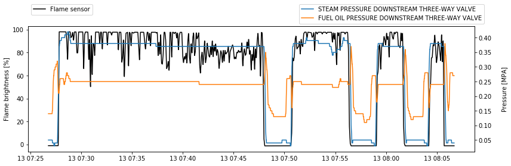

#### Lets focus on first attempt only now. Find the oil temperature for an hour before the first attempt, and at the moment of first attempt.

```python
sub6 = df.copy()
sub7 = df.copy()
sub6 = sub6[sub6['BURNER FLAME SENSOR, BURNER 4']>0]
sub6['timestamp'] = pd.to_datetime(sub6['timestamp'])
sub7['timestamp'] = pd.to_datetime(sub7['timestamp'])
sub7 = sub7.set_index('timestamp')
print('Oil temperature at the moment of first attempt was {}°C and one hour before it was equal to {}°C'
      .format(sub6.loc[sub6.index[0], 'FUEL OIL TEMPERATURE (DEG C)'],
              sub7.loc[sub6.loc[sub6.index[0],'timestamp']-dt.timedelta(hours=1), 'FUEL OIL TEMPERATURE (DEG C)']))
```

```
Oil temperature at the moment of first attempt was 107.58°C and one hour before it was equal to 96.45°C
```

```
Oil temperature at the moment of first attempt was 107.58°C and one hour before it was equal to 96.45°C
```

#### For the first attempt again: find the warmup time (from the moment when steam started flowing to the burner, to the moment the first attempt was made)

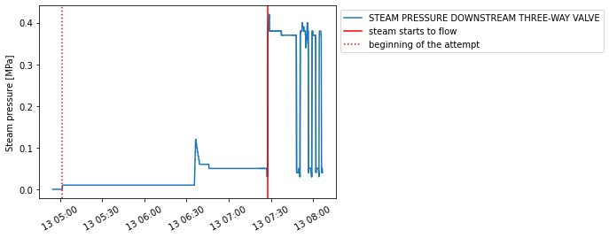

```python
sub8 = df.copy()
sub8['timestamp'] = pd.to_datetime(sub8['timestamp'])
sub8['active'] = sub8.apply(lambda x: 1 if x['STEAM PRESSURE DOWNSTREAM THREE-WAY VALVE'] > 0
                            and x['STEAM PRESSURE DOWNSTREAM THREE-WAY VALVE'] < 0.4 else 0, axis=1)
sub8['active_dif'] = sub8['active'].diff()
sub8['active2'] = sub8.apply(lambda x: 2 if x['STEAM PRESSURE DOWNSTREAM THREE-WAY VALVE'] > 0.3 else 0, axis=1)
sub8['active_dif2'] = sub8['active2'].diff()
sub8 = sub8.set_index('timestamp')
starts = sub8[sub8['active_dif']==1]
ends = sub8[sub8['active_dif']==-1]
starts2 = sub8[sub8['active_dif2']==2]
ends2 = sub8[sub8['active_dif2']==-2]
margin = dt.timedelta(seconds=59)
plt.figure(figsize=(6,4));
plt.ylabel('Steam pressure [MPa]');
plt.xlabel(None);

for n, (start, end) in enumerate (zip(starts.index, ends.index)):
    if n < 3:
        plt.plot(sub8.loc[start-7*margin:end+11*margin, 'STEAM PRESSURE DOWNSTREAM THREE-WAY VALVE'], color='tab:blue',
                label='STEAM PRESSURE DOWNSTREAM THREE-WAY VALVE', )

for i, start in enumerate (starts2.index):
    if i == 0:
        plt.axvline(x=start, color='red', label="steam starts to flow", linestyle='-')

for j, start in enumerate (starts.index):
    if j == 0:
        plt.axvline(x=start, color='red', label="beginning of the attempt", linestyle=':')

handles, labels = plt.gca().get_legend_handles_labels()
by_label = dict(zip(labels, handles))
plt.legend(by_label.values(), by_label.keys(), loc='upper left', bbox_to_anchor=(1,1));
plt.xticks(rotation=30)
plt.show()
```

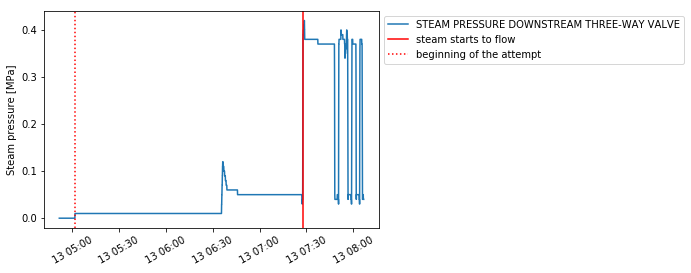

```python
begin_w = sub8[sub8['active']==1]
begin_date = begin_w.index[2]
end_w = sub8[sub8['active2']==2]
end_date = end_w.index[0]
time = (end_date-begin_date).total_seconds()
print('Before the first attempt the burner was warmed up for ABOUT {} hours'.format(time/3600))
# Gives the same answer

# I think this is more accurate:
begin_date2 = begin_w.index[0]
time2 = (end_date-begin_date2).total_seconds()
print('Before the first attempt the burner was warmed up for ABOUT {} hours'.format(time2/3600))
```

```
Before the first attempt the burner was warmed up for ABOUT 2.4338888888888888 hours
Before the first attempt the burner was warmed up for ABOUT 2.4344444444444444 hours
```

```python
print(f"Before the first attempt the burner was warmed up for ABOUT {warmup.seconds/3600} hours")
```

```
Before the first attempt the burner was warmed up for ABOUT 2.4338888888888888 hours
```

#### Find the mean steam temperature during the warmup period

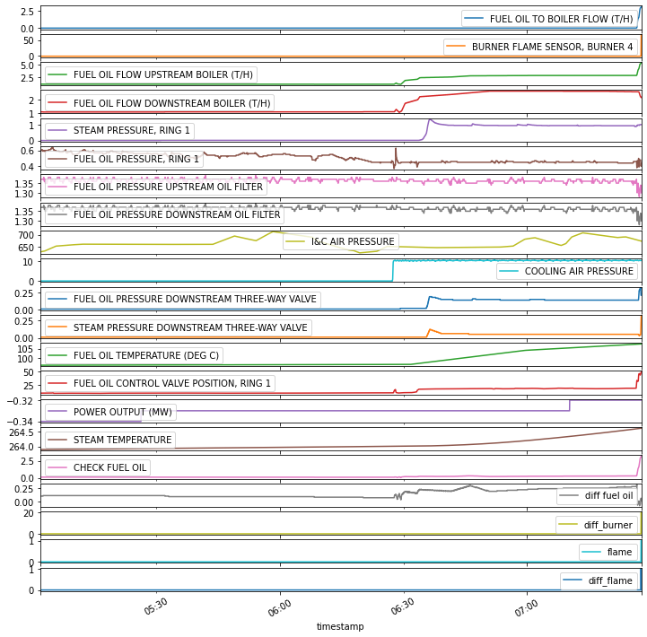

```python
sub9 = df.copy()
sub9['timestamp'] = pd.to_datetime(sub9['timestamp'])
sub9 = sub9.set_index('timestamp')
sub9['CHECK FUEL OIL'] = sub9.apply(lambda x: x['FUEL OIL FLOW UPSTREAM BOILER (T/H)'] -
                                  x['FUEL OIL FLOW DOWNSTREAM BOILER (T/H)'], axis=1)
sub9['diff fuel oil'] = sub9.apply(lambda x: x['CHECK FUEL OIL'] - x['FUEL OIL TO BOILER FLOW (T/H)'], axis=1)
sub9['diff_burner'] = sub9.apply(lambda x: 20 if x['BURNER FLAME SENSOR, BURNER 4']>0 else 0, axis=1)
sub9['flame'] = sub9.apply(lambda x: 1 if x['BURNER FLAME SENSOR, BURNER 4']>0 else 0, axis=1)
sub9['diff_flame'] = sub9['flame'].diff()
sub9.loc[begin_date:end_date].plot(subplots=True, figsize=(12,12), rot=30);
```

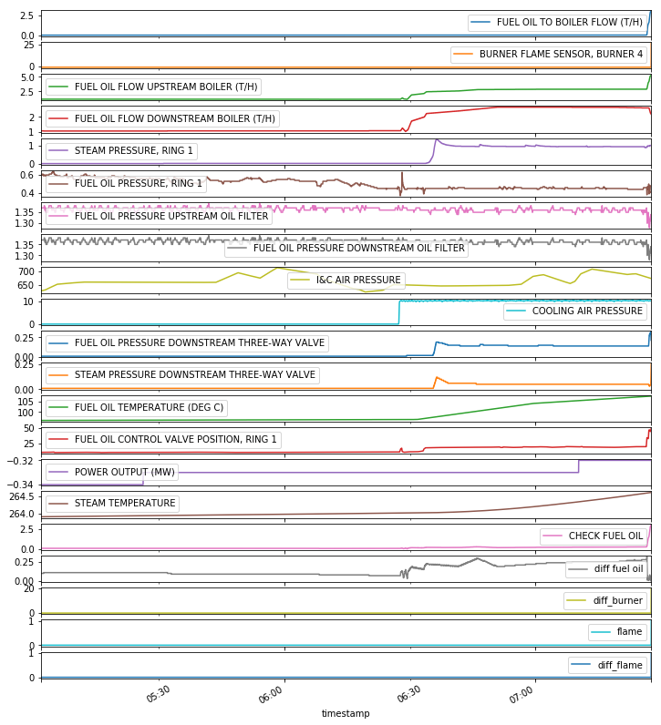

```python
print('Mean steam temperature during warmup: {}°C'.
      format(round(sub9.loc[begin_date:end_date,'STEAM TEMPERATURE'].mean(),2)))
```

```
Mean steam temperature during warmup: 264.06°C
```

```
Mean steam temperature during warmup: 264.06°C
```